# Pokemon Characteristics and Classification

Imen Bouzidi

11/3/2019

## Data Set:

Pokemon dataset contains information on a total of 801 Pokemon.

it includes:

- The English name of the Pokemon
- percentage_male: The percentage of the species that are male. Blank if the Pokemon is genderless.
- height_m: Height of the Pokemon in metres
- weight_kg: The Weight of the Pokemon in kilograms
- hp: The Base HP of the Pokemon
- attack: The Base Attack of the Pokemon
- defense: The Base Defense of the Pokemon
- speed: The Base Speed of the Pokemon
- base_egg_steps: The number of steps required to hatch an egg of the Pokemon
- base_happiness: Base Happiness of the Pokemon
- capture_rate: Capture Rate of the Pokemon
- experience_growth: The Experience Growth of the Pokemon
- sp_attack: The Base Special Attack of the Pokemon
- sp_defense: The Base Special Defense of the Pokemon
- type1: The Primary Type of the Pokemon (18 type)
- generation: The numbered generation which the Pokemon was first introduced
- is_legendary: Denotes if the Pokemon is legendary.

Data are downloaded from: https://www.kaggle.com/rounakbanik/pokemon/data

```r
D=read.csv('Pokemon.csv',header = T,row.names = 1)
library(DT)
datatable(D, rownames = 1, filter="top", options = list(pageLength = 5, scrollX=T) )
```

| names | percentage_male | height_m | weight_kg | hp | attack | defense | speed | base_egg_steps | base_happiness | capture_rate | experience_growth | sp_attack | sp_defense | type1 | generation | is_legendary |
| --- | --- | --- | --- | --- | --- | --- | --- | --- | --- | --- | --- | --- | --- | --- | --- | --- |
| Bulbasaur | 88.1 | 0.7 | 6.9 | 45 | 49 | 49 | 45 | 5120 | 70 | 45 | 1059860 | 65 | 65 | grass | 1 | 0 |
| Ivysaur | 88.1 | 1 | 13 | 60 | 62 | 63 | 60 | 5120 | 70 | 45 | 1059860 | 80 | 80 | grass | 1 | 0 |
| Venusaur | 88.1 | 2 | 100 | 80 | 100 | 123 | 80 | 5120 | 70 | 45 | 1059860 | 122 | 120 | grass | 1 | 0 |
| Charmander | 88.1 | 0.6 | 8.5 | 39 | 52 | 43 | 65 | 5120 | 70 | 45 | 1059860 | 60 | 50 | fire | 1 | 0 |
| Charmeleon | 88.1 | 1.1 | 19 | 58 | 64 | 58 | 80 | 5120 | 70 | 45 | 1059860 | 80 | 65 | fire | 1 | 0 |
| Charizard | 88.1 | 1.7 | 90.5 | 78 | 104 | 78 | 100 | 5120 | 70 | 45 | 1059860 | 159 | 115 | fire | 1 | 0 |
| Squirtle | 88.1 | 0.5 | 9 | 44 | 48 | 65 | 43 | 5120 | 70 | 45 | 1059860 | 50 | 64 | water | 1 | 0 |
| Wartortle | 88.1 | 1 | 22.5 | 59 | 63 | 80 | 58 | 5120 | 70 | 45 | 1059860 | 65 | 80 | water | 1 | 0 |
| Blastoise | 88.1 | 1.6 | 85.5 | 79 | 103 | 120 | 78 | 5120 | 70 | 45 | 1059860 | 135 | 115 | water | 1 | 0 |
| Caterpie | 50 | 0.3 | 2.9 | 45 | 30 | 35 | 45 | 3840 | 70 | 255 | 1000000 | 20 | 20 | bug | 1 | 0 |

[output cut: 791 more lines]

```r
summary(D)
```

```
##         names     percentage_male     height_m        weight_kg
##  Abomasnow :  1   Min.   :  0.00   Min.   : 0.100   Min.   :  0.10
##  Abra      :  1   1st Qu.: 50.00   1st Qu.: 0.600   1st Qu.:  9.00
##  Absol     :  1   Median : 50.00   Median : 1.000   Median : 27.30
##  Accelgor  :  1   Mean   : 55.16   Mean   : 1.164   Mean   : 61.38
##  Aegislash :  1   3rd Qu.: 50.00   3rd Qu.: 1.500   3rd Qu.: 64.80
##  Aerodactyl:  1   Max.   :100.00   Max.   :14.500   Max.   :999.90
##  (Other)   :795   NA's   :98       NA's   :20       NA's   :20
##        hp             attack          defense           speed
##  Min.   :  1.00   Min.   :  5.00   Min.   :  5.00   Min.   :  5.00
##  1st Qu.: 50.00   1st Qu.: 55.00   1st Qu.: 50.00   1st Qu.: 45.00
##  Median : 65.00   Median : 75.00   Median : 70.00   Median : 65.00
##  Mean   : 68.96   Mean   : 77.86   Mean   : 73.01   Mean   : 66.33
##  3rd Qu.: 80.00   3rd Qu.:100.00   3rd Qu.: 90.00   3rd Qu.: 85.00
##  Max.   :255.00   Max.   :185.00   Max.   :230.00   Max.   :180.00
##
##  base_egg_steps  base_happiness    capture_rate    experience_growth
##  Min.   : 1280   Min.   :  0.00   Min.   :  3.00   Min.   : 600000
##  1st Qu.: 5120   1st Qu.: 70.00   1st Qu.: 45.00   1st Qu.:1000000
##  Median : 5120   Median : 70.00   Median : 60.00   Median :1000000
##  Mean   : 7191   Mean   : 65.36   Mean   : 98.76   Mean   :1054996
##  3rd Qu.: 6400   3rd Qu.: 70.00   3rd Qu.:170.00   3rd Qu.:1059860
##  Max.   :30720   Max.   :140.00   Max.   :255.00   Max.   :1640000
##                                   NA's   :1
##    sp_attack        sp_defense         type1       generation
##  Min.   : 10.00   Min.   : 20.00   water  :114   Min.   :1.00
##  1st Qu.: 45.00   1st Qu.: 50.00   normal :105   1st Qu.:2.00
##  Median : 65.00   Median : 66.00   grass  : 78   Median :4.00
##  Mean   : 71.31   Mean   : 70.91   bug    : 72   Mean   :3.69
##  3rd Qu.: 91.00   3rd Qu.: 90.00   psychic: 53   3rd Qu.:5.00
##  Max.   :194.00   Max.   :230.00   fire   : 52   Max.   :7.00
##                                    (Other):327
##   is_legendary
##  Min.   :0.00000
##  1st Qu.:0.00000
##  Median :0.00000
##  Mean   :0.08739
##  3rd Qu.:0.00000
##  Max.   :1.00000
##
```

## PCA on Characteristics of Pokemons:

Variables from height_m to sp_defense are the quantitatives variables for the PCA.

Supplementary qualitative variable are generation and ‘is_legendary’.

```r
library("FactoMineR")
library('factoextra')
```

```r
library('missMDA')

impData=imputePCA(D[,3:14], ncp = 2, scale = TRUE, method = c("Regularized","EM")) # impute missing data

PcaData=data.frame(cbind(impData[["completeObs"]],D[,16:17]))

res.pca = PCA(PcaData[,1:14], graph = FALSE,quali.sup = c(13,14))

head(res.pca$eig,4)
```

```
##        eigenvalue percentage of variance cumulative percentage of variance
## comp 1  4.6406574              38.672145                          38.67214
## comp 2  1.3770799              11.475666                          50.14781
## comp 3  1.2355183              10.295986                          60.44380
## comp 4  0.8768248               7.306873                          67.75067
```

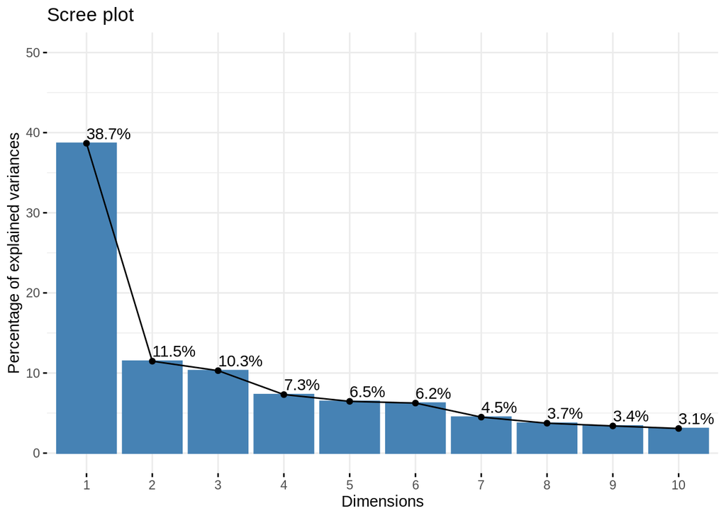

```r
fviz_eig(res.pca, addlabels = TRUE, ylim = c(0, 50))
```

In our case, we are studying 3 dimensions (60.44% of the information with an eigenvalue >1)

### Visualizing the first 2 dimensions:

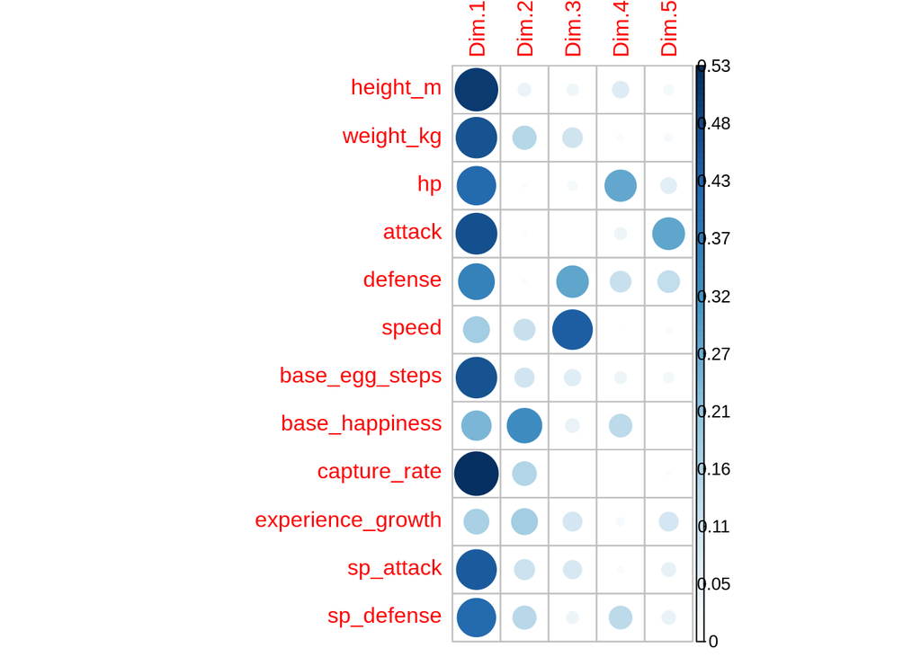

```r
library("corrplot")
corrplot(res.pca$var$cos2, is.corr=FALSE)
```

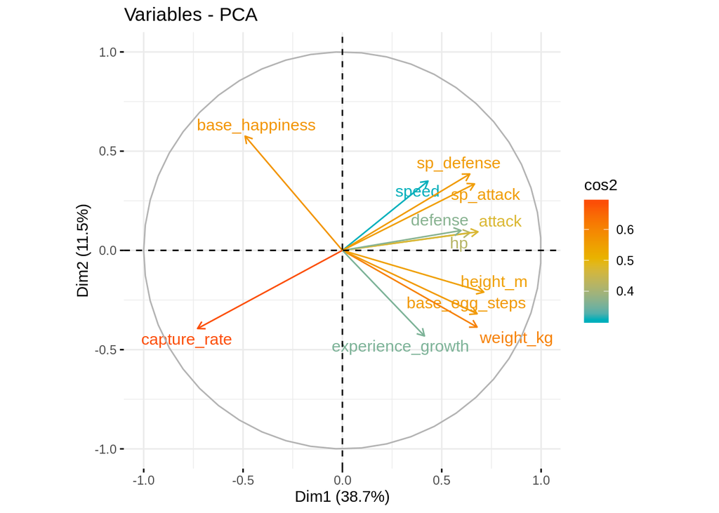

```r
fviz_pca_var(res.pca, col.var = "cos2",
             gradient.cols = c("#00AFBB", "#E7B800", "#FC4E07"),repel = T
             )
```